# Glider Deployment Report

## risso (April 14, 2025)

### Summary

The Ecosystem Science Division (ESD) at the Southwest Fisheries Science Center (SWFSC) deployed glider **risso** (unit_1025) on 2025-04-14 off the coast of **San Diego, CA** (32.77<sup>o</sup>N, -117.31<sup>o</sup>W) (Figure 1). Sensors deployed on the glider are listed in Table 1.

Figure 1 (A) displays tracklines of glider during deployment, while (B) displays the broad deployment area. The glider remained deployed for 15 days, performed 309 dives, and traveled a total of 318.33 km while diving to a maximum depth of 511.9 m. The glider was recovered on 2025-04-28.

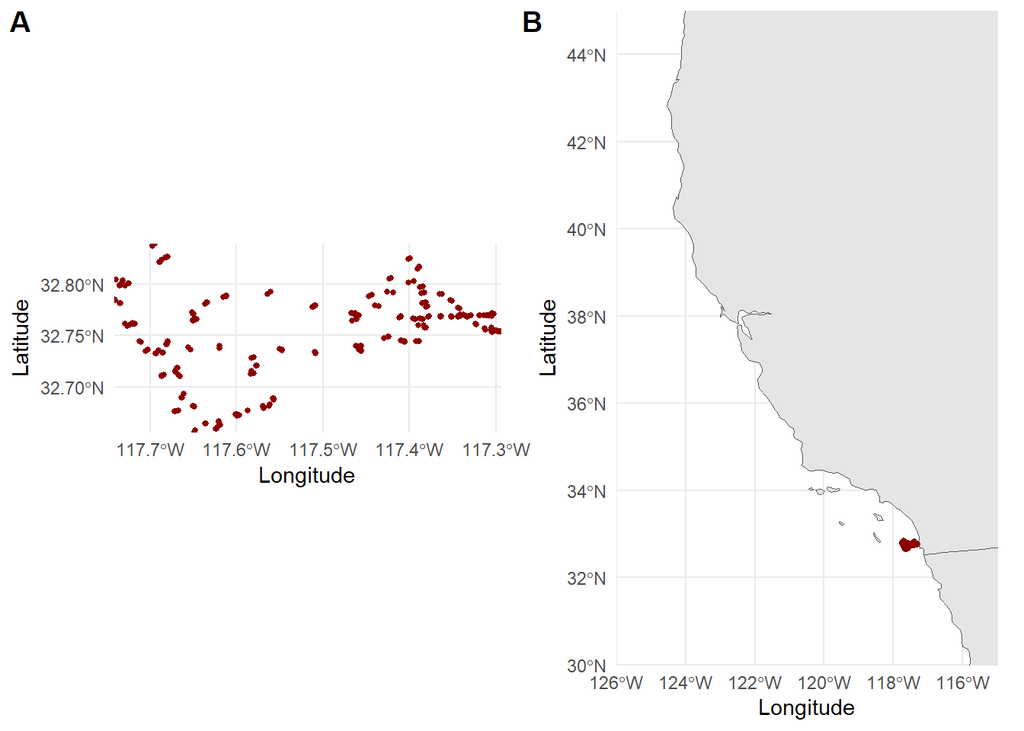

Figure 1: Glider tracklines. A displays close-up tracklines, while B displays the broad deployment area.

Table 1: Science sampling strategies for current glider deployment. Additional settings for the Williamson and Associates camera and the Nortek echosounder (if installed) are defined in configuration and initialization files on the glider’s science computer, and are also housed on the Google Cloud Platform. All deployment files are available on request.

| File Name | Sensor | State to Sample | Depth to Sample | Serial Number |
| --- | --- | --- | --- | --- |
| sample01.ma | Sea-Bird Conductivity Temperature Depth (CTD) (SBE-41) | See Table 2 | 1000 m | 10049 |
| sample48.ma | Sea-Bird ECO Puck (backscatter and fluorescence) (FLBBCD-SLC, CDOM) | See Table 2 | 1000 m | 8869 |
| sample54.ma | AANDERAA oxygen optode (4831) | See Table 2 | 1000 m | 1132 |
| sample56.ma | Photosynthetically active radiation (QSP-2150, Biospherical Instruments, Inc.) | See Table 2 | 1000 m | 50423 |
| sample49.ma | Passive acoustic monitor (DMON2, Woods Hole Oceanographic Institution) | Diving, hovering, climbing | 1000 m | 68 |

The glider was deployed in tandem with a second glider (“stenella”). Each glider was equipped with a different passive acoustic monitor (PAM), and the goals of this deployment were to 1) compare passive acoustic data between the two sensors; 2) evaluate any potential interference in passive acoustic data caused by other sensors on the gliders, and 3) determine battery consumption of new sensors (passive acoustic and photosynthetically active radiation sensors). All sensors except PAMs were systematically turned off and on throughout the deployment to isolate interference and to better assess battery usage.

### Introduction

The Ecosystem Science Division at NOAA Fisheries’ Southwest Fisheries Science Center monitors the living marine resources within the Southern Ocean and the California Current in order to satisfy the requirements of several legislative mandates to support conservation and management decision-making. To achieve this goal, we use autonomous underwater buoyancy-driven gliders with integrated sensors for measuring ocean conditions, plankton densities, and marine mammal distributions.

Depending on the specific deployment objective, Slocum gliders are equipped with a suite of sensors. We obtain acoustic estimates of zooplankton density (primarily Antarctic krill in the Southern Ocean) using one of two different echosounders: an Acoustic Zooplankton Fish Profiler with discrete frequencies at 67.5 and 125 kHz (AZFP, ASL, Inc) and a mini-Signature 100 wideband echosounder with continuous frequencies between 70 and 120 kHz (Nortek). We also collect ancillary oceanographic data (temperature, salinity, dissolved oxygen, chlorophyll, colored dissolved organic matter, backscatter, and photosynthetically active radiation) to characterize the marine environment. Additional sensors may include passive acoustic monitors for marine mammal detection (“Wispr”, Embedded Ocean Systems; digital acoustic monitoring “DMON”, Woods Hole Oceanographic Institution), “glidercams” for verifying acoustic targets (Williamson and Associates, Inc.) and shadowgraph cameras for obtaining imagery of the plankton community (Williamson and Associates, Inc.). Imagery is used to train artificial intelligence (AI) models to automate plankton identification.

Hefring OceanScout gliders are equipped with conductivity-temperature-depth sensors (CTDs; RBR, Inc.) and “Wispr” passive acoustic monitors.

### Pre-deployment preparation and testing

Prior to deployment, the ESD has a standard protocol for preparing and testing gliders to minimize or eliminate issues that may occur due to human error during deployment:

*Slocum gliders*

1. Gliders are properly ballasted (i.e., weighted) so that the density of the glider matches the density of the water in which it will be deployed. Weight and flotation configurations are documented
2. The junctions between glider sections are thoroughly cleaned, old o-rings are discarded, new o-rings are inspected for damage that may compromise their ability to form a water-tight seal, new o-rings are properly lubricated, and the glider is sealed together. All cable connections are photographed to document the “final seal” and ensure the glider was reassembled properly
3. A “Functional Checkout” is performed to ensure and document that all glider systems and science sensors are functioning properly. During the Functional Checkout, we verify the battery type installed in the glider (lithium primary or lithium rechargeable) and that the appropriate battery duration (total coulomb amp hours) is active in the glider’s autoexec.mi file
4. Two test missions are performed in the SWFSC test tank (20 m x 10 m x 10 m) to ensure the glider is performing as expected
5. Once per year, glider compasses are calibrated (the compass was not calibrated prior to this deployment)
6. Biofouling prevention measures are applied as necessary
7. Glider flight and science sampling files are prepared according to mission objectives. These objectives are identified by the Principal Investigators for each deployment. Files are uploaded to the Teledyne Webb Research Slocum Fleet Mission Control (SFMC) web interface and sent to the glider just prior to deployment over the Iridium connection
8. When gliders are shipped to their deployment location, ESD glider technicians perform a second Functional Checkout to ensure the gliders function properly after transit

### Deployment-specific testing

ESD staff prepared this glider for deployment in February 2025; however, during the Functional Checkout procedure, the valve in the oil pump did not appear to be opening and closing properly (set_for_ballasting(): Error valve never closed). Teledyne staff were on site and ran repeated tests, including a recalibration of the oil pump. Teledyne advised against a deployment, as this valve issue may have prevented the glider from pumping oil into the nose to inflect at depth, resulting in the glider sinking and dispatching its ejection weight. The forward section was returned to Teledyne for service. ESD staff swapped out the faulty forward section (SN 0688) for a different forward section (SN 0693). During the Functional Checkout procedure prior to the current deployment, the valve issue was observed again and was reproducible only after issuing the “ballast” command after an exit reset (when the oil was retracting to its neutral position). Staff performed an extended “wiggle” and watched the oil volume change on the computer terminal and did not observe the valve issue again. ESD staff determined that it was safe to proceed with deployment (see March 3, 2025 email “NOAA Unit 1025 Valve Issue”).

### Deployment

“risso” was deployed on April 14, 2025, approximately 5 km west of Mission Bay in the Pacific Ocean (32.77<sup>o</sup>N, -117.31<sup>o</sup>W) from the ESD Zodiac R/V *Ernest II*. This glider was deployed with the sensor configuration listed above, and with lithium rechargeable batteries (coulomb amp hour total = 215, no extended energy bay). We began this deployment using the autoballast feature to maximize oil pump efficiency. Autoballast converged successfully early on and remained converged for the duration of the deployment.

Because Randome digifins are sensitive to slight movements and produce erroneous oddities that can lead to mission aborts, the following commands were issued to the glider prior to sequencing our standard mission (1k_n.mi):

put u_digifin_hide_oddities_at_surface 1 put u_digifin_mask_movement_warning_at_surface 1

The glider did not complete its first deployment test mission (status.mi) successfully because m_raw_altitude was not reporting. Pilots issued the “use” command and determined that the wrong altimeter was installed in the glider’s autoexec.mi file. Pilots fixed the error and re-sent the autoexec.mi file to the glider, after which status.mi completed normally. No other issues or problems were noted during deployment activities.

One abort occurred during the deployment for a leak in the digifin, approximately 5.5 hours after the glider was deployed. This issue has been observed before, nearly always when the glider surfaces normally for “nothing commanded” and is reading a surfacing script. While digifins are unlikely to leak, pilots exercised caution and obtained several digifin leakdetect readings to ensure all values were within normal range (greater than 1019). The low value that triggered the abort did not appear on the surface sensor plot or in the .sbd file, further confirming that the leak was false. Pilots commanded the fin to 0.3 and -0.3 and the measured values matched. Pilots then resequenced the mission and started with one dive to 50 m to ensure the fin was functioning properly. When the glider surfaced after the 50 m dive, pilots paused the surfacing script and issued the following command:

!put u_digifin_leakdetect_count 10

This command increases the number of consecutive leakdetect readings the glider requires to abort its mission from the masterdata default of 5 to 10. While low digifin leakdetect readings were observed in the surface dialogue on subsequent surfacings, they always rebounded to normal values almost immediately and did not cause any additional aborts. We did not observe any evidence of a leak in the fin upon recovery.

This glider performed well for the entire 15-day mission. The glider used 77.97 amp hours over 15 days, or 36.27% of its battery capacity.

Throughout the deployment, pilots systematically turned all science sensors (except the PAM) on and off to evaluate whether noise from these sensors affected the quality of PAM data. The PAM remained on for the duration of the deployment. Other sensors were cycled on and off according to Table 2. When sensors were on, they sampled only on dives.

Table 2: Sampling strategies for sensors to determine whether individual sensors interfere with passive acoustic data. Sensors were systematically turned off and on throughout the deployment to isolate interence. Time is in UTC.

| Date | Time | Sensor | On.Off |
| --- | --- | --- | --- |
| 2025-04-11 | 22:24:42 | CTD | On |
| 2025-04-11 | 22:24:42 | ECO Puck | On |
| 2025-04-11 | 22:24:42 | Optode | On |
| 2025-04-11 | 22:24:42 | PAR | On |
| 2025-04-15 | 17:17:09 | ECO Puck | Off |
| 2025-04-15 | 17:17:09 | Optode | Off |
| 2025-04-15 | 17:17:09 | PAR | Off |
| 2025-04-16 | 16:34:05 | CTD | Off |
| 2025-04-16 | 16:34:05 | ECO Puck | On |
| 2025-04-17 | 18:35:07 | ECO Puck | Off |
| 2025-04-17 | 18:35:07 | Optode | On |
| 2025-04-18 | 15:52:00 | Optode | Off |
| 2025-04-18 | 15:52:00 | PAR | On |
| 2025-04-19 | 17:52:38 | PAR | Off |
| 2025-04-20 | 19:47:37 | CTD | On |
| 2025-04-20 | 19:47:37 | ECO Puck | On |
| 2025-04-20 | 19:47:37 | Optode | On |
| 2025-04-20 | 19:47:37 | PAR | On |

Unlike the “Wispr” PAM on the glider “stenella,” pilots are unable to modify DMON settings during a deployment. DMON settings were configured prior to deployment for continuous recording of the low-frequency hydrophone at 2 kHz and duty-cycled recording of the high-frequency hydrophone at 120 kHz for 30 seconds out of every 450 seconds.

### Post-Deployment Actions

Once the glider was back in the laboratory, pilots attempted downloading data using the comms cable connection and the high-speed setting that allows us to maximize the baud rate of the freewave (hs on). Pilots found that they were unable to communicate with the glider over the ZOC terminal once the comms cable was connected, even if the USB end of the cable was not connected to the computer. Pilots tried switching comm ports between the freewave and the comms cable on the computer without success. Pilots tried using Tera Term instead of ZOC and were able to communicate with the glider after the comms cable was connected and to switch to the high baud rate, but the connection repeatedly timed out when pilots attempted to download data and no files were transferred. Pilots opened the glider and downloaded all data directly from SD cards. Pilots suspect the issue may be related to the software version and will investigate.

Calculations related to battery consumption remain to be done.